# Lab 2: Data Summaries and Complex Numbers

Nicole Barbour

2024-05-18

# Load In Processed Data

We will load in the processed elk data we created in the previous exercise.

```r
load(file="./data/elk_processed.rda")

head(elk_processed)
```

```
##              datetime       lon      lat   id
## 1 2001-12-13 07:01:00 -115.8043 52.12410 4049
## 2 2001-12-13 09:01:00 -115.8003 52.11762 4049
## 3 2001-12-14 09:01:00 -115.8281 52.09611 4049
## 4 2001-12-14 11:00:00 -115.8318 52.09829 4049
## 5 2001-12-14 17:02:00 -115.8042 52.09482 4049
## 6 2001-12-14 19:01:00 -115.8037 52.12493 4049
```

# Select Individuals

## Create a Summary Table of Tracks

```r
library(dplyr)
```

Before selecting individuals we wish to use for our analyses, it’s helpful to create a data frame that summarizes tracks by their tracking durations.

The `difftime` function is useful for determining the difference in time between successive time points.

```r
elk_processed |> group_by(id) |>
  summarize(Min_Time = min(datetime),
            Max_Time = max(datetime),
            Duration = round(difftime(max(datetime), min(datetime), units = "days")))
```

```
## # A tibble: 31 × 4
##    id    Min_Time            Max_Time            Duration
##    <chr> <dttm>              <dttm>              <drtn>
##  1 4049  2001-12-13 07:01:00 2002-11-14 03:00:00 336 days
##  2 GP1   2003-03-25 19:01:00 2003-03-30 01:00:00   4 days
##  3 GP2   2003-03-15 01:00:00 2004-01-04 09:01:00 295 days
##  4 GR104 2004-03-29 19:00:00 2005-01-22 15:00:00 299 days
##  5 GR182 2002-04-05 07:01:00 2002-12-17 17:00:00 256 days
##  6 GR193 2002-04-05 23:01:00 2002-11-23 15:01:00 232 days
##  7 GR196 2002-04-05 23:00:00 2002-06-15 08:30:00  70 days
##  8 YL15  2003-02-16 13:00:00 2004-01-06 05:01:00 324 days
##  9 YL2   2003-02-14 05:00:00 2004-01-14 19:02:00 335 days
## 10 YL25  2003-03-03 22:06:00 2004-03-26 11:00:00 389 days
## # ℹ 21 more rows
```

It’s also helpful to use the `summary` function to generate summary statistics for the tracking duration of *all* the individuals in our dataset.

Looks like there are some very short tracks that we might want to drop!

```r
elk_processed |> group_by(id) |>
  summarize(time_range = as.numeric(difftime(max(datetime), min(datetime), units ="days"))) |>
  summary()
```

```
##       id              time_range
##  Length:31          Min.   :  4.249
##  Class :character   1st Qu.:170.636
##  Mode  :character   Median :269.000
##                     Mean   :231.225
##                     3rd Qu.:308.727
##                     Max.   :388.538
```

## Visualize Tracking Durations

We can use the “ggplot2” package to visualize the tracking durations for all individuals.

```r
library(ggplot2)
```

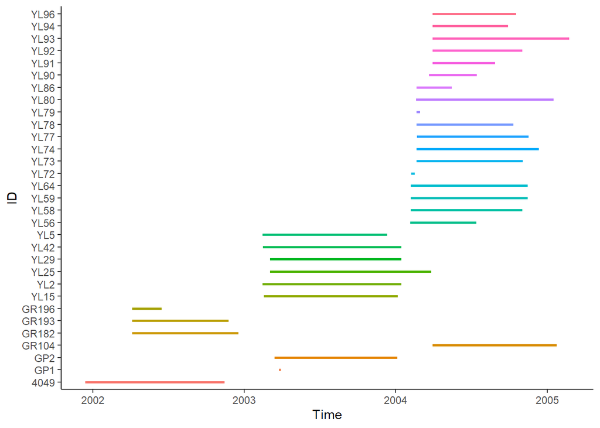

```r
ggplot(data = elk_processed, aes(x = datetime,y = id, color = id))+
  geom_path(linewidth=1) +
  theme_classic() +
  xlab("Time") + ylab("ID")+
  theme(legend.position = "none")
```

## Drop Individuals with Short Tracks

Using the `subset` function combine with the “%in%” operator and the “!” condition (meaning “not equal to”), we can select only for the individuals *without* very short tracks.

```r
elk_processed2 <- subset(elk_processed, !id %in% c("GP1", "YL72", "YL79"))
```

The tracks look much better now!

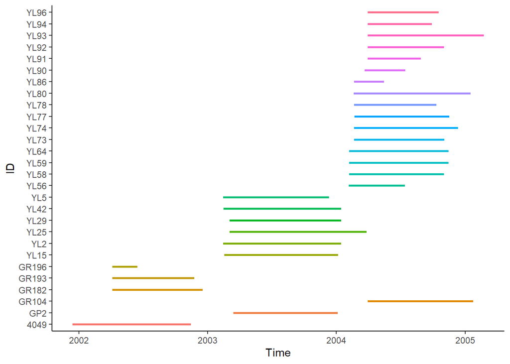

```r
ggplot(data = elk_processed2, aes(x = datetime, y = id, color = id))+
  geom_path(linewidth=1) +
  theme_classic() +
  xlab("Time") + ylab("ID")+
  theme(legend.position = "none")
```

# Convert Coordinates Into Complex Numbers

Complex data compress multi-dimensional data (e.g., X, Y polar coordinates) into one number. This is very useful for calculations used in movement ecology, such as determining the displacement distance or turning angles between successive locations.

The formula to create a complex number (Z) from polar coordinates (X, Y) is: Z = X + iY

In this formula, “i” represents a constant and the polar coordinates, X and Y, are referred to as the “real” and “imaginary” portions of the complex number.

## Convert CRS to Projected Coordinate System

Before converting our locations to complex numbers, we first need to make our data spatial and then project the coordinate reference system (CRS) to one with measurable units (e.g., UTM, in meters).

We can use the `st_transform` function for this, specifying UTM Zone 11 North for our elk data (EPSG Code: 32611).

```r
library(sf)
```

```r
elk_utm <- elk_processed2 |>
  st_as_sf(coords = c("lon", "lat"), crs = 4326) |>
  st_transform(32611)

elk_utm
```

```
## Simple feature collection with 138097 features and 2 fields
## Geometry type: POINT
## Dimension:     XY
## Bounding box:  xmin: 541357.9 ymin: 5693120 xmax: 614407.5 ymax: 5778807
## Projected CRS: WGS 84 / UTM zone 11N
## First 10 features:
##               datetime   id                 geometry
## 1  2001-12-13 07:01:00 4049 POINT (581853.4 5775515)
## 2  2001-12-13 09:01:00 4049 POINT (582144.6 5774799)
## 3  2001-12-14 09:01:00 4049 POINT (580275.7 5772376)
## 4  2001-12-14 11:00:00 4049 POINT (580022.5 5772614)
## 5  2001-12-14 17:02:00 4049 POINT (581917.3 5772259)
## 6  2001-12-14 19:01:00 4049 POINT (581896.4 5775608)
## 7  2001-12-14 21:00:00 4049 POINT (582253.3 5775719)
## 8  2001-12-15 01:01:00 4049 POINT (582370.2 5773419)
## 9  2001-12-15 03:01:00 4049 POINT (583071.8 5771568)
## 10 2001-12-15 05:01:00 4049   POINT (580562 5772726)
```

Now we can extract the matrix of projected coordinates for our data with the `st_coordinates` function, passing the X and Y information as individual columns in our sf data.

```r
xy_coords <- st_coordinates(elk_utm)

elk_processed2$X <- xy_coords[,1]
elk_processed2$Y <- xy_coords[,2]
```

## Calculate Complex Locations

Now that we have X and Y columns in our data, we can plug these into our complex number formula to get complex locations (Z)!

```r
elk_processed2$Z <- elk_processed2$X + 1i*elk_processed2$Y
```

We can also do this using the `complex` function (see `?complex` for more info).

```r
elk_processed2$Z <- complex(re = elk_processed2$X, im = elk_processed2$Y)
```

```r
str(elk_processed2)
```

```
## 'data.frame':    138097 obs. of  7 variables:
##  $ datetime: POSIXct, format: "2001-12-13 07:01:00" "2001-12-13 09:01:00" ...
##  $ lon     : num  -116 -116 -116 -116 -116 ...
##  $ lat     : num  52.1 52.1 52.1 52.1 52.1 ...
##  $ id      : chr  "4049" "4049" "4049" "4049" ...
##  $ X       : num  581853 582145 580276 580023 581917 ...
##  $ Y       : num  5775515 5774799 5772376 5772614 5772259 ...
##  $ Z       : cplx  581853+5775515i 582145+5774799i 580276+5772376i ...
```

# Visualize Tracks (Multiple Dimensions)

We can use Base R to create a plot with the X/Y coordinates for each individual, showing changes in X/Y over space and changes in X vs Y over time. This is a helpful way to visually identify where movement-based behaviors may be occurring within a track.

```r
GP1 <- subset(elk_processed2, id == "GP1")

lpar(mar = c(0,4,0,0), oma = c(4,0,5,2), xpd=NA)
layout(rbind(c(1,2), c(1,3)))
plot(GP1$X, GP1$Y, asp = 1, type="o", ylab="Latitude", xlab="Longitude")
plot(GP1$datetime, GP1$X, type="o", xaxt="n", ylab="Longitude", xlab="")
plot(GP1$datetime, GP1$Y, type="o", ylab="Latitude", xlab="Datetime")
title(paste("ID", GP1$id[1]), outer = TRUE)
```

[output not shown]

We can also do this for all individuals, using the methods we learned in lab 1, but this time for data with X and Y coordinates, not lat/lon.

```r
plotTrack_XY <- function(dataframe){
  par(mar = c(0,4,0,0), oma = c(4,0,5,2), xpd=NA)
  layout(rbind(c(1,2), c(1,3)))
  plot(dataframe$X, dataframe$Y, asp = 1, type="o", ylab="Latitude", xlab="Longitude")
  plot(dataframe$datetime, dataframe$X, type="o", xaxt="n", ylab="Longitude", xlab="")
  plot(dataframe$datetime, dataframe$Y, type="o", ylab="Latitude", xlab="Datetime")
  title(paste("ID", dataframe$id[1]), outer = TRUE)
}
```

```r
detach("package:dplyr", unload=TRUE)

library(plyr)

library(dplyr)
```

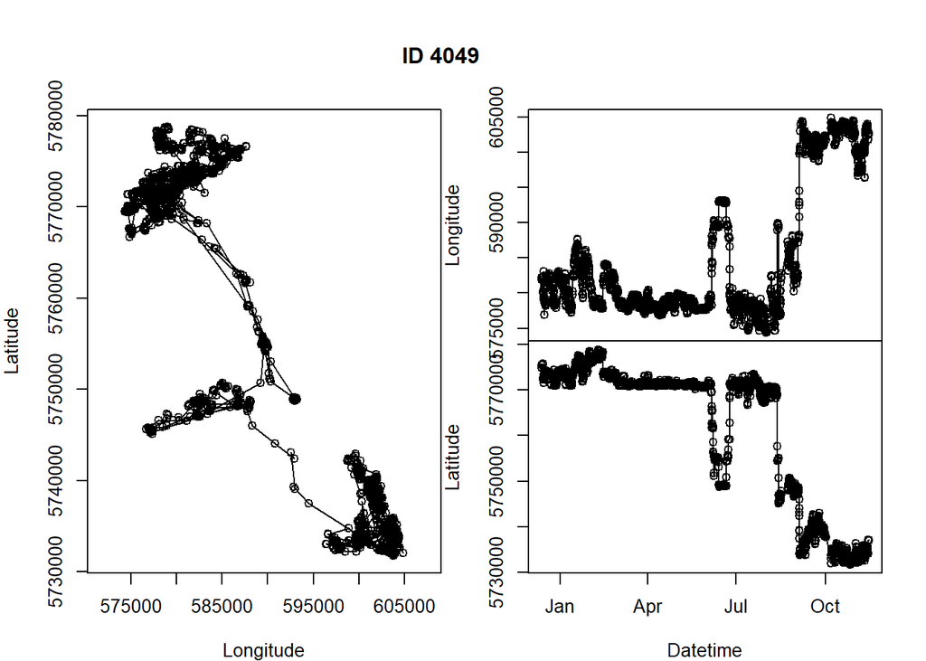

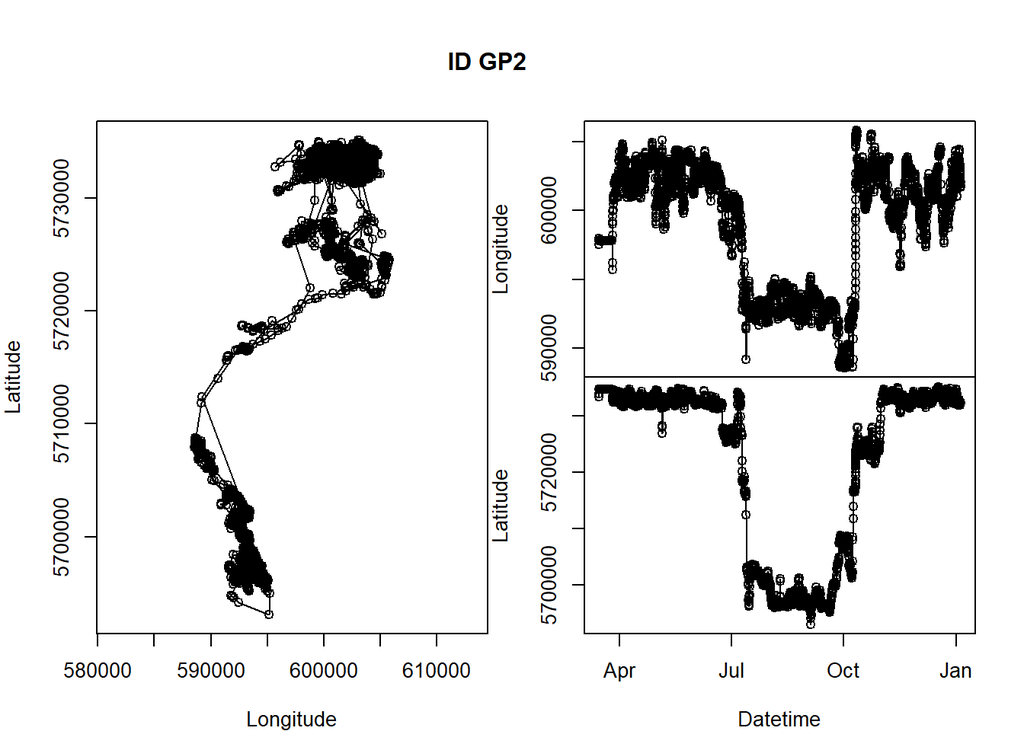

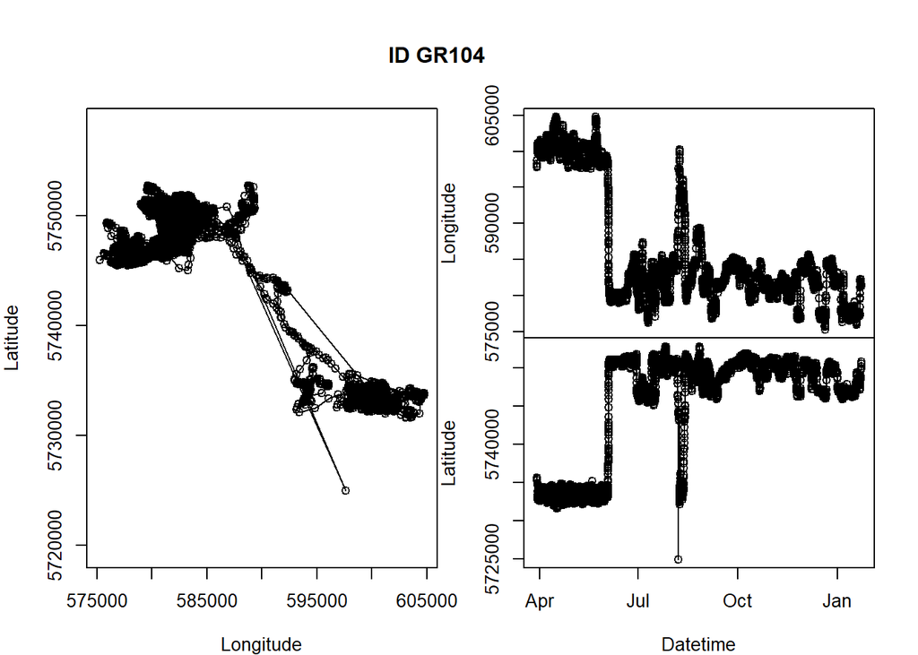

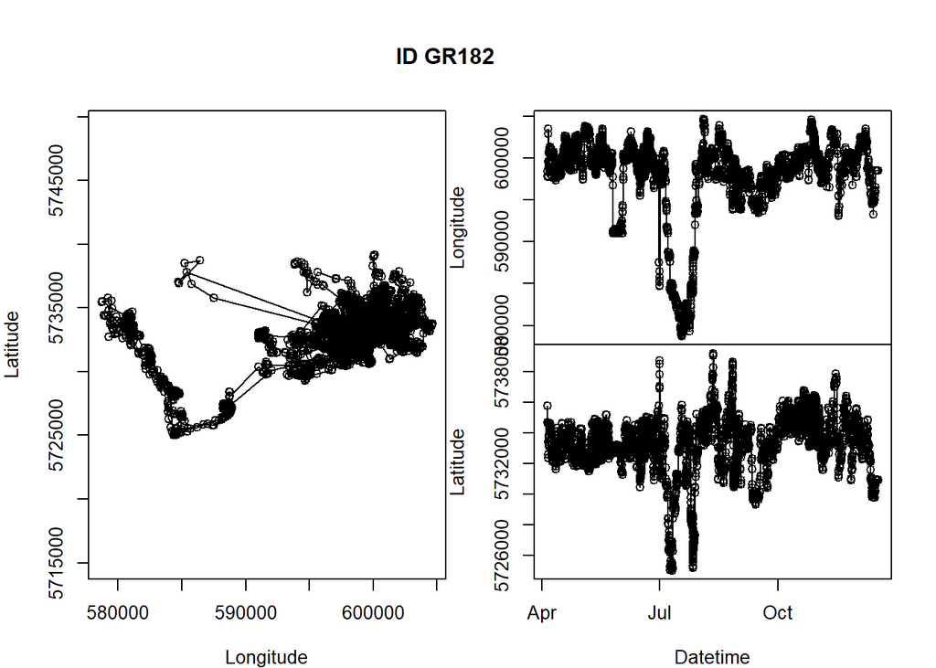

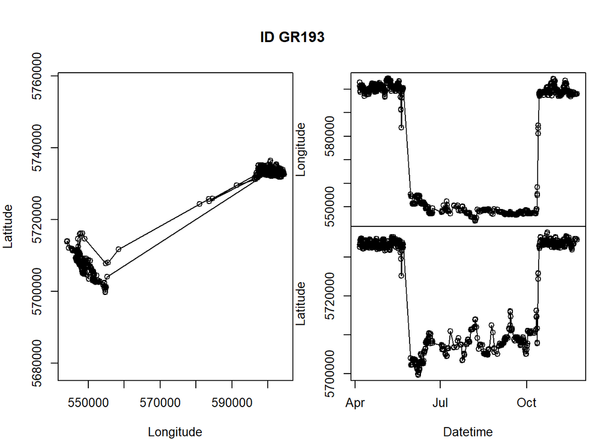

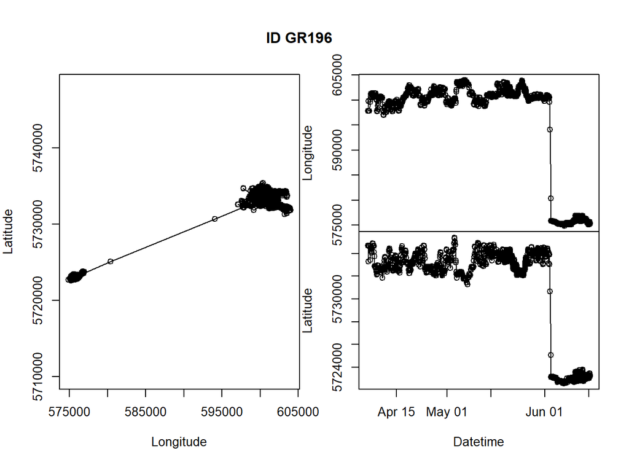

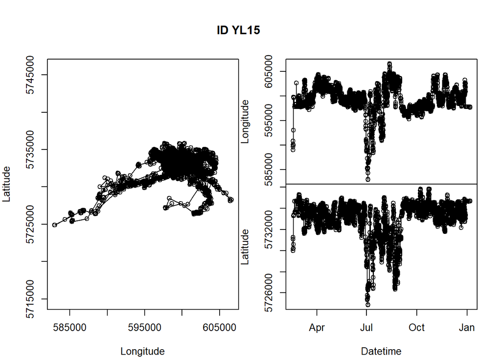

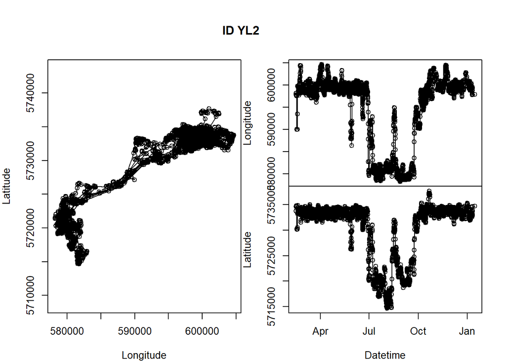

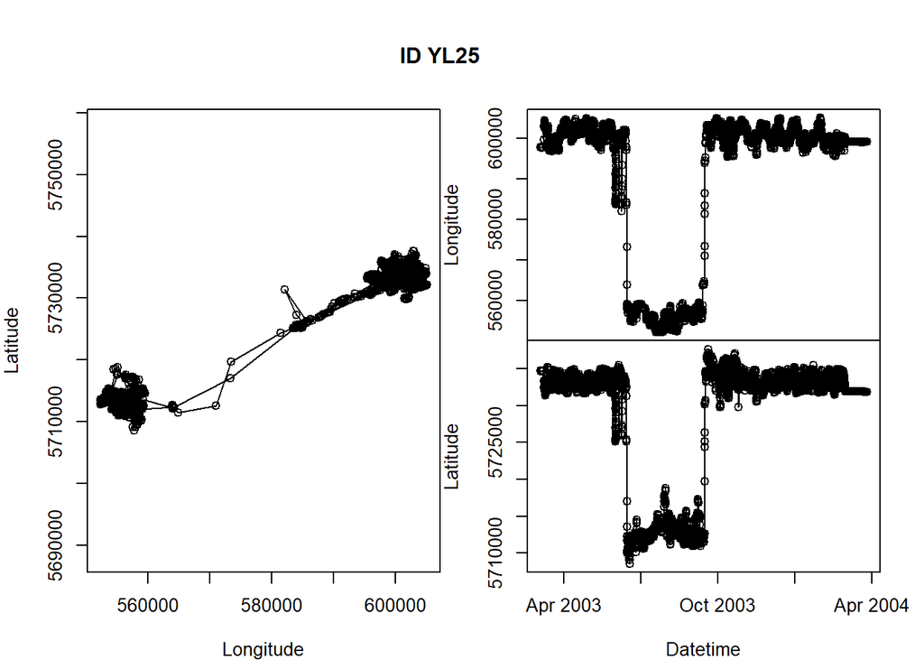

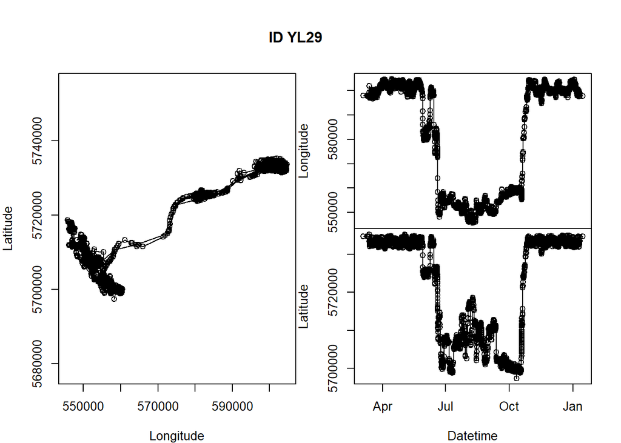

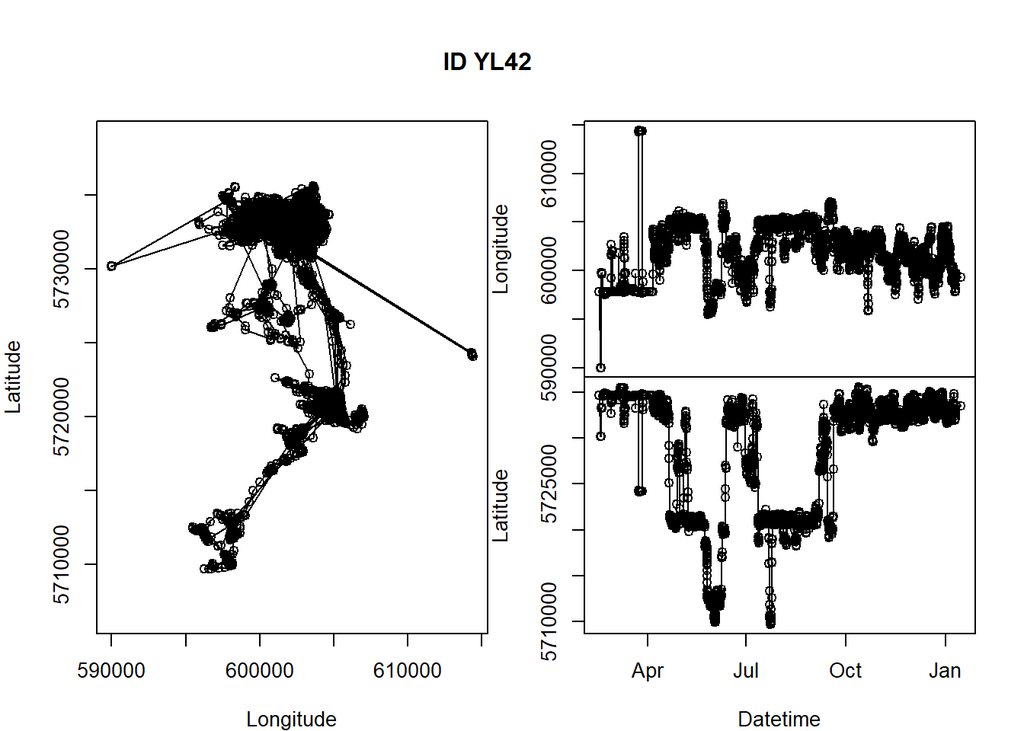

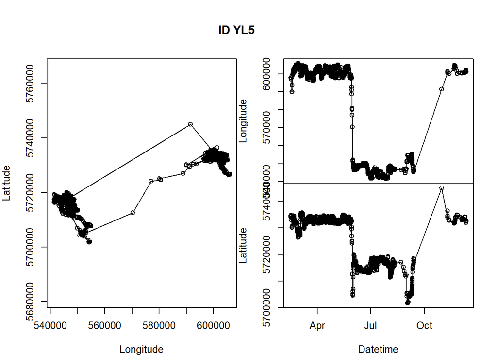

[16 more figures not shown]

```r
elk_processed2 |> d_ply("id", plotTrack_XY)
```

# Calculate Movement Metrics

Now that we have our data as complex locations, we can easily quantify useful movement metrics for our elk, such as step lengths (straight line displacement between consecutive locations) and relative turning angles (difference in absolute direction between consecutive locations).

Following our rule of “generalizable” data processing, we will create a function that calculates these movement metrics for each individual.

The step length, also called the “Modulus”, can be calculated with the formula: sqrt(X^2 + Y^2). It can also be extracted from a complex number with the function `Mod()`. The absolute angle between locations is called the “Argument” and can be extracted from a complex number with the function “Arg()”. For more information, see the help file `?complex`.

## Define Function

We define our function in the code chunk below, assigning it a name and an input object (“dataframe”). The function will return the same dataframe but annotated with the new movement metrics we calculate in the function.

```r
getMovementMetrics <- function(dataframe){

  move_step <- diff(dataframe$Z)

  time_step <- as.numeric(difftime(dataframe$datetime[-1], dataframe$datetime[-length(dataframe$datetime)], "days"))

  absolute_turnangle <- Arg(move_step)

  relative_turnangle <- diff(absolute_turnangle)

  step_length_km <- Mod(move_step)/1000

  dataframe$time_step_days <- c(NA, time_step)

  dataframe$move_rate_km_day <- c(NA, step_length_km/time_step)

  dataframe$step_length_km <- c(NA, step_length_km)

  dataframe$relative_turnangle <- c(NA, NA, relative_turnangle)

  return(dataframe)
}
```

## Calculate for All Individuals At Once

Now that we have a function that will calculate and annotate the movement metrics for an individual’s dataframe, we can use a couple different functions in R to run our function on all of our individuals at once.

The first is the `lapply` function. First, we have to convert our elk dataframe into a list of dataframes for each id. We can do this using the `split` function.

```r
elk_id <- split(elk_processed2, elk_processed2$id)
```

Now we can use `lapply` to apply our function to each element in our list. The resulting object is also a list, with each element being an individual dataframe, now annotated with the movement metrics.

We can convert our elk list object back to one big dataframe using the `do.call` function.

```r
elk_id_move <- lapply(elk_id,
                         getMovementMetrics)

elk_move <- do.call("rbind", elk_id_move)

str(elk_move)
```

```
## 'data.frame':    138097 obs. of  11 variables:
##  $ datetime          : POSIXct, format: "2001-12-13 07:01:00" "2001-12-13 09:01:00" ...
##  $ lon               : num  -116 -116 -116 -116 -116 ...
##  $ lat               : num  52.1 52.1 52.1 52.1 52.1 ...
##  $ id                : chr  "4049" "4049" "4049" "4049" ...
##  $ X                 : num  581853 582145 580276 580023 581917 ...
##  $ Y                 : num  5775515 5774799 5772376 5772614 5772259 ...
##  $ Z                 : cplx  581853+5775515i 582145+5774799i 580276+5772376i ...
##  $ time_step_days    : num  NA 2 24 1.98 6.03 ...
##  $ move_rate_km_day  : num  NA 0.387 0.128 0.175 0.32 ...
##  $ step_length_km    : num  NA 0.773 3.06 0.348 1.928 ...
##  $ relative_turnangle: num  NA NA -1.04 4.61 -2.57 ...
```

The other method, which is even more efficient, uses the “`ddply` function from the”plyr” R package.

```r
elk_move<- elk_processed2 |>
  plyr::ddply("id", getMovementMetrics)

str(elk_move)
```

```
## 'data.frame':    138097 obs. of  11 variables:
##  $ datetime          : POSIXct, format: "2001-12-13 07:01:00" "2001-12-13 09:01:00" ...
##  $ lon               : num  -116 -116 -116 -116 -116 ...
##  $ lat               : num  52.1 52.1 52.1 52.1 52.1 ...
##  $ id                : chr  "4049" "4049" "4049" "4049" ...
##  $ X                 : num  581853 582145 580276 580023 581917 ...
##  $ Y                 : num  5775515 5774799 5772376 5772614 5772259 ...
##  $ Z                 : cplx  581853+5775515i 582145+5774799i 580276+5772376i ...
##  $ time_step_days    : num  NA 2 24 1.98 6.03 ...
##  $ move_rate_km_day  : num  NA 0.387 0.128 0.175 0.32 ...
##  $ step_length_km    : num  NA 0.773 3.06 0.348 1.928 ...
##  $ relative_turnangle: num  NA NA -1.04 4.61 -2.57 ...
```

# Visualize and Summarize Movement Metrics

## Check the Fix Rate

Checking the fix rate, we can see that the data is irregular in time, meaning that step lengths are not comparable over the tracks but the movement rate (km/day) is. For future analyses with discrete time assumptions, we may need to regularize our data to account for large gaps or irregular fix rates in the data.

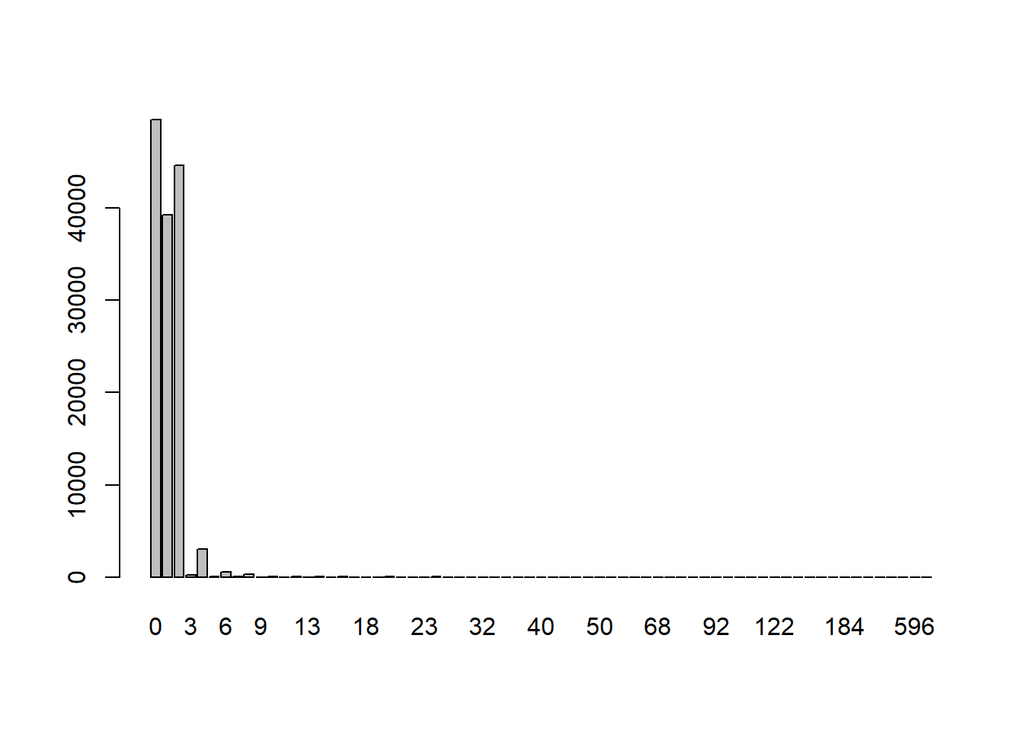

```r
dtime <- function(t, ...) {difftime(t[-1], t[-length(t)], ...) %>% as.numeric}

fix_rate <- elk_move |>
  group_by(id) |>
  arrange(datetime) |>
  mutate(dtime = c(0,round(dtime(datetime, units ="hours")))) |>
  data.frame() |>
  ungroup()

barplot(table(fix_rate$dtime))
```

## Summarize the Fix Rate and Movement Rate

We can use similar methods to previously to summarize our move metrics.

```r
summary(fix_rate$dtime)
```

```
##     Min.  1st Qu.   Median     Mean  3rd Qu.     Max.
##    0.000    0.000    1.000    1.152    2.000 1135.000
```

```r
summary(elk_move$move_rate_km_day)
```

```
##     Min.  1st Qu.   Median     Mean  3rd Qu.     Max.     NA's
## 0.000000 0.000670 0.002064 0.021030 0.006186 3.823224       28
```

```r
elk_move |>
  group_by(id) |>
  filter(is.na(move_rate_km_day)==FALSE) |>
  summarize(Min_MoveRate = min(move_rate_km_day),
            Max_MoveRate = max(move_rate_km_day),
            Avg_MoveRate = mean(move_rate_km_day))
```

```
## # A tibble: 28 × 4
##    id    Min_MoveRate Max_MoveRate Avg_MoveRate
##    <chr>        <dbl>        <dbl>        <dbl>
##  1 4049    0                3.82        0.147
##  2 GP2     0                0.0619      0.00317
##  3 GR104   0                0.386       0.00405
##  4 GR182   0                0.128       0.00439
##  5 GR193   0.000173         1.77        0.145
##  6 GR196   0.00000575       0.0504      0.00328
##  7 YL15    0                0.140       0.00290
##  8 YL2     0                0.117       0.00342
##  9 YL25    0                0.142       0.00362
## 10 YL29    0                0.0797      0.00399
## # ℹ 18 more rows
```

## Visualize Step Lengths and Turning Angles

Visualizing step lengths and turning angles is useful for informing analyses, such as various segmentation methods (e.g., Hidden Markov Models).

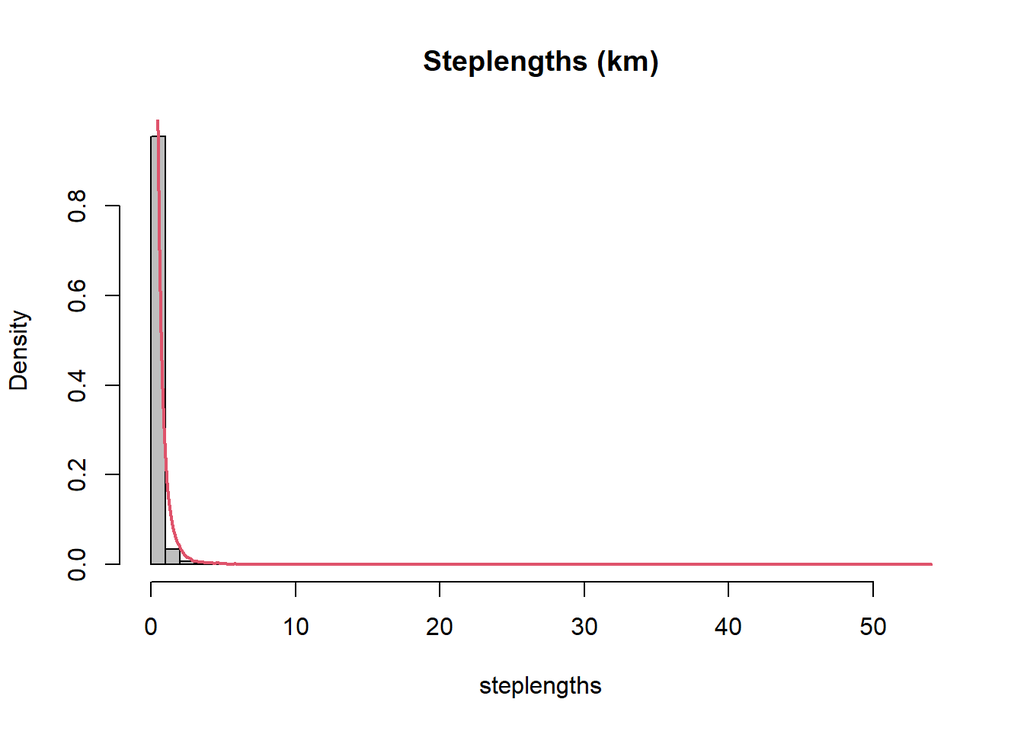

```r
steplengths <- na.omit(elk_move$step_length_km)

hist(steplengths, col="grey", bor="black", freq=FALSE, breaks=50, main ="Steplengths (km)")
lines(density(steplengths), col=2, lwd=2)
```

```r
library(circular)
```

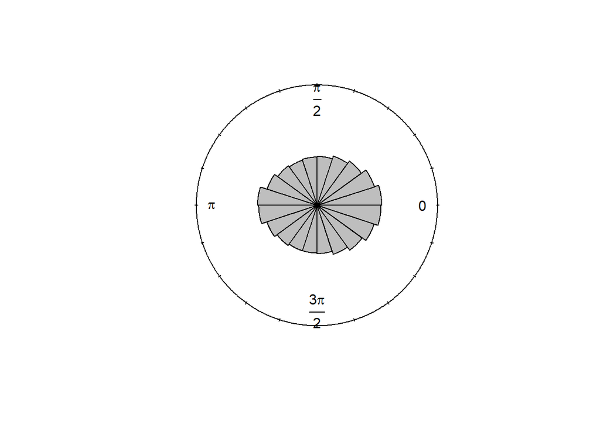

```r
turningangles <- as.circular(na.omit(elk_move$relative_turnangle))

rose.diag(turningangles, bins=20, col="grey", prop=2)
```